# Homework5

Author

Yuner Rao

## Problem 1.1

1.1.1 Class Definition and Constructor

```r
# class definition and constructor
setClass(
  "waldCI",
  slots = c(
    mean = "numeric",
    sterr = "numeric",
    level = "numeric"
  )
)

# Helper function: critical value
z_value <- function(level) {
  qnorm((1 - level) / 2, lower.tail = FALSE)
}

# Helper function: check finite numeric scalar
is_scalar <- function(x) {
  is.numeric(x) && length(x) == 1 && is.finite(x)
}

# Custom constructor
makeCI <- function(level, mean = NULL, sterr = NULL,
                   lb = NULL, ub = NULL) {

  if (!is_scalar(level) || level <= 0 || level >= 1) {
    stop("Confidence level must be between 0 and 1.")
  }

  if (!is.null(mean) && !is.null(sterr) &&
      is.null(lb) && is.null(ub)) {

    obj <- new("waldCI",
               mean = mean,
               sterr = sterr,
               level = level)

  } else if (!is.null(lb) && !is.null(ub) &&
             is.null(mean) && is.null(sterr)) {

    if (!is_scalar(lb) || !is_scalar(ub)) {
      stop("Bounds must be finite numeric scalars.")
    }

    if (lb > ub) {
      stop("Lower bound cannot exceed upper bound.")
    }

    obj <- new("waldCI",
               mean = lb / 2 + ub / 2,
               sterr = (ub / 2 - lb / 2) / z_value(level),
               level = level)

  } else {
    stop("Provide either mean and sterr, or lb and ub.")
  }

  validObject(obj)
  return(obj)
}
```

1.1.2 Valudator

```r
setValidity("waldCI", function(object) {

  if (!is_scalar(object@mean)) {
    return("Mean must be a finite numeric scalar.")
  }

  if (!is_scalar(object@sterr) || object@sterr < 0) {
    return("Standard error must be finite and non-negative.")
  }

  if (!is_scalar(object@level) ||
      object@level <= 0 || object@level >= 1) {
    return("Confidence level must be between 0 and 1.")
  }

  z <- z_value(object@level)

  lower <- object@mean - z * object@sterr
  upper <- object@mean + z * object@sterr

  if (!is.finite(lower) || !is.finite(upper)) {
    return("Confidence bounds must be finite.")
  }

  if (lower > upper) {
    return("Lower bound cannot exceed upper bound.")
  }

  return(TRUE)
})
```

```
Class "waldCI" [in ".GlobalEnv"]

Slots:

Name:     mean   sterr   level
Class: numeric numeric numeric
```

1.1.3 Show Method

```r
setMethod("show", "waldCI", function(object) {

  z <- z_value(object@level)

  lower <- object@mean - z * object@sterr
  upper <- object@mean + z * object@sterr

  cat("Wald Confidence Interval\n")
  cat("Confidence level:", object@level * 100, "%\n")
  cat("Mean:", object@mean, "\n")
  cat("Standard error:", object@sterr, "\n")
  cat("Interval: [", lower, ", ", upper, "]\n", sep = "")
})
```

1.1.4 Accessors

```r
# Define generic functions
setGeneric("lb", function(x) standardGeneric("lb"))
```

```
[1] "lb"
```

```r
setGeneric("ub", function(x) standardGeneric("ub"))
```

```
[1] "ub"
```

```r
setGeneric("sterr", function(x) standardGeneric("sterr"))
```

```
[1] "sterr"
```

```r
setGeneric("level", function(x) standardGeneric("level"))
```

```
[1] "level"
```

```r
setGeneric("mean")
```

```
[1] "mean"
```

```r
# Lower bound
setMethod("lb", "waldCI", function(x) {
  x@mean - z_value(x@level) * x@sterr
})

# Upper bound
setMethod("ub", "waldCI", function(x) {
  x@mean + z_value(x@level) * x@sterr
})

# Mean
setMethod("mean", "waldCI", function(x, ...) {
  x@mean
})

# Standard error
setMethod("sterr", "waldCI", function(x) {
  x@sterr
})

# Confidence level
setMethod("level", "waldCI", function(x) {
  x@level
})
```

1.1.5 Setters

```r
# Define replacement generics
setGeneric("lb<-", function(x, value) {
  standardGeneric("lb<-")
})
```

```
[1] "lb<-"
```

```r
setGeneric("ub<-", function(x, value) {
  standardGeneric("ub<-")
})
```

```
[1] "ub<-"
```

```r
setGeneric("mean<-", function(x, value) {
  standardGeneric("mean<-")
})
```

```
[1] "mean<-"
```

```r
setGeneric("sterr<-", function(x, value) {
  standardGeneric("sterr<-")
})
```

```
[1] "sterr<-"
```

```r
setGeneric("level<-", function(x, value) {
  standardGeneric("level<-")
})
```

```
[1] "level<-"
```

```r
# Lower bound setter
setReplaceMethod("lb", "waldCI", function(x, value) {

  x <- makeCI(
    level = level(x),
    lb = value,
    ub = ub(x)
  )

  validObject(x)
  return(x)
})

# Upper bound setter
setReplaceMethod("ub", "waldCI", function(x, value) {

  x <- makeCI(
    level = level(x),
    lb = lb(x),
    ub = value
  )

  validObject(x)
  return(x)
})

# Mean setter
setReplaceMethod("mean", "waldCI", function(x, value) {

  x@mean <- value
  validObject(x)
  return(x)
})

# Standard error setter
setReplaceMethod("sterr", "waldCI", function(x, value) {

  x@sterr <- value
  validObject(x)
  return(x)
})

# Confidence level setter
setReplaceMethod("level", "waldCI", function(x, value) {

  x@level <- value
  validObject(x)
  return(x)
})
```

1.1.6 Contains Method

```r
setGeneric("contains", function(x, value) {
  standardGeneric("contains")
})
```

```
[1] "contains"
```

```r
setMethod(
  "contains",
  signature(x = "waldCI", value = "numeric"),
  function(x, value) {
    value >= lb(x) & value <= ub(x)
  }
)
```

1.1.7 Overlap Method

```r
setGeneric("overlap", function(x, y) {
  standardGeneric("overlap")
})
```

```
[1] "overlap"
```

```r
setMethod(
  "overlap",
  signature(x = "waldCI", y = "waldCI"),
  function(x, y) {
    lb(x) <= ub(y) && lb(y) <= ub(x)
  }
)
```

1.1.8 As.numeric Method

```r
setGeneric("as.numeric")
```

```
[1] "as.numeric"
```

```r
setMethod("as.numeric", "waldCI", function(x, ...) {
  c(lb(x), ub(x))
})
```

1.1.9 TransformCI Method

```r
setGeneric("transformCI", function(x, fun) {
  standardGeneric("transformCI")
})
```

```
[1] "transformCI"
```

```r
setMethod(
  "transformCI",
  signature(x = "waldCI", fun = "function"),
  function(x, fun) {

    warning("Only monotonic transformations make sense.")

    points <- seq(lb(x), ub(x), length.out = 1000)

    transformed <- vapply(points, fun, numeric(1))

    # Check for non-finite values
    if (any(!is.finite(transformed))) {
      stop("Transformation produces non-finite values.")
    }

    differences <- diff(transformed)

    increasing <- all(differences >= 0)
    decreasing <- all(differences <= 0)

    if (!increasing && !decreasing) {
      stop("The function is not monotonic on the interval.")
    }

    # Transform the endpoints
    bounds <- c(fun(lb(x)), fun(ub(x)))

    # Return a new waldCI object
    makeCI(
      level = level(x),
      lb = min(bounds),
      ub = max(bounds)
    )
  }
)
```

The `waldCI` class stores the mean, standard error, and confidence level as three numeric slots. The lower and upper bounds are calculated from these quantities to avoid redundant information and maintain internal consistency. All setters validate the resulting object before returning it.

For `transformCI`, monotonicity is approximately checked using 1,000 equally spaced points within the original confidence interval. Both increasing and decreasing transformations are supported by taking the minimum and maximum of the transformed endpoints. This numerical approach does not guarantee mathematical monotonicity. For nonlinear transformations, the new mean and standard error are reconstructed from the transformed bounds.

## Problem 1.2

```r
# Create three confidence intervals
ci1 <- makeCI(level = 0.95, lb = 17.2, ub = 24.7)
ci2 <- makeCI(level = 0.99, mean = 13, sterr = 2.5)
ci3 <- makeCI(level = 0.75, lb = 27.43, ub = 39.22)

# Display the objects
ci1
```

```
Wald Confidence Interval
Confidence level: 95 %
Mean: 20.95
Standard error: 1.9133
Interval: [17.2, 24.7]
```

```r
ci2
```

```
Wald Confidence Interval
Confidence level: 99 %
Mean: 13
Standard error: 2.5
Interval: [6.560427, 19.43957]
```

```r
ci3
```

```
Wald Confidence Interval
Confidence level: 75 %
Mean: 33.325
Standard error: 5.12453
Interval: [27.43, 39.22]
```

```r
# Convert to numeric vectors
as.numeric(ci1)
```

```
[1] 17.2 24.7
```

```r
as.numeric(ci2)
```

```
[1]  6.560427 19.439573
```

```r
as.numeric(ci3)
```

```
[1] 27.43 39.22
```

```r
# Test accessors
lb(ci2)
```

```
[1] 6.560427
```

```r
ub(ci2)
```

```
[1] 19.43957
```

```r
mean(ci1)
```

```
[1] 20.95
```

```r
sterr(ci3)
```

```
[1] 5.12453
```

```r
level(ci2)
```

```
[1] 0.99
```

```r
# Test setters
lb(ci2) <- 10.5
mean(ci3) <- 34
level(ci3) <- .8

# Display the updated objects
ci2
```

```
Wald Confidence Interval
Confidence level: 99 %
Mean: 14.96979
Standard error: 1.735281
Interval: [10.5, 19.43957]
```

```r
ci3
```

```
Wald Confidence Interval
Confidence level: 80 %
Mean: 34
Standard error: 5.12453
Interval: [27.43265, 40.56735]
```

```r
# Test contains and overlap
contains(ci1, 17)
```

```
[1] FALSE
```

```r
contains(ci3, 44)
```

```
[1] FALSE
```

```r
overlap(ci1, ci2)
```

```
[1] TRUE
```

```r
# Test transformations
eci1 <- transformCI(ci1, sqrt)
eci1
```

```
Wald Confidence Interval
Confidence level: 95 %
Mean: 4.558599
Standard error: 0.2098562
Interval: [4.147288, 4.969909]
```

```r
mean(transformCI(ci2, log))
```

```
Warning in transformCI(ci2, log): Only monotonic transformations make sense.
```

```
[1] 2.659343
```

All three confidence intervals are successfully constructed, and the accessors return the expected values. After applying the setters, `ci2` becomes [10.5, 19.43957], while `ci3` becomes [27.43265, 40.56735] with an 80% confidence level.

These results demonstrate that all implemented methods work as intended for the given examples.

## Problem 1.3

```r
# Negative standard error
try(makeCI(level = 0.95, mean = 20, sterr = -2))
```

```
Error in validObject(.Object) :
  invalid class "waldCI" object: Standard error must be finite and non-negative.
```

```r
# Lower bound greater than upper bound
try(makeCI(level = 0.95, lb = 30, ub = 20))
```

```
Error in makeCI(level = 0.95, lb = 30, ub = 20) :
  Lower bound cannot exceed upper bound.
```

```r
# Infinite bounds
try(makeCI(level = 0.95, lb = -Inf, ub = 20))
```

```
Error in makeCI(level = 0.95, lb = -Inf, ub = 20) :
  Bounds must be finite numeric scalars.
```

```r
try(makeCI(level = 0.95, lb = 10, ub = Inf))
```

```
Error in makeCI(level = 0.95, lb = 10, ub = Inf) :
  Bounds must be finite numeric scalars.
```

```r
try(lb(ci1) <- 100)
```

```
Error in makeCI(level = level(x), lb = value, ub = ub(x)) :
  Lower bound cannot exceed upper bound.
```

```r
try(ub(ci1) <- 0)
```

```
Error in makeCI(level = level(x), lb = lb(x), ub = value) :
  Lower bound cannot exceed upper bound.
```

```r
try(mean(ci1) <- Inf)
```

```
Error in validObject(x) :
  invalid class "waldCI" object: Mean must be a finite numeric scalar.
```

```r
try(sterr(ci1) <- -5)
```

```
Error in validObject(x) :
  invalid class "waldCI" object: Standard error must be finite and non-negative.
```

```r
try(level(ci1) <- 1.5)
```

```
Error in validObject(x) :
  invalid class "waldCI" object: Confidence level must be between 0 and 1.
```

```r
# Directly test the S4 validator
try(new("waldCI", mean = 10, sterr = -2, level = 0.95))
```

```
Error in validObject(.Object) :
  invalid class "waldCI" object: Standard error must be finite and non-negative.
```

```r
validObject(ci1)
```

```
[1] TRUE
```

```r
ci1
```

```
Wald Confidence Interval
Confidence level: 95 %
Mean: 20.95
Standard error: 1.9133
Interval: [17.2, 24.7]
```

All invalid confidence intervals are successfully rejected by the constructor or validator, including negative standard errors, incorrectly ordered bounds, infinite bounds, and invalid setter operations. The direct use of `new()` also produces an error for an invalid object, confirming that validation is enforced at the class level.

Finally, `validObject(ci1)` returns `TRUE`, and the original 95% confidence interval remains unchanged at [17.2, 24.7]. These results demonstrate that the validation mechanisms work as intended for all tested cases.

## Problem 2(a)

```r
# import data
library(data.table)
tennis <- fread(
  "https://raw.githubusercontent.com/azhou5849/tennis-atp-sackmann-data/master/atp_matches_2019.csv"
)

head(tennis)
```

```
   tourney_id tourney_name surface draw_size tourney_level tourney_date
       <char>       <char>  <char>     <int>        <char>        <int>
1:  2019-M020     Brisbane    Hard        32             A     20181231
2:  2019-M020     Brisbane    Hard        32             A     20181231
3:  2019-M020     Brisbane    Hard        32             A     20181231
4:  2019-M020     Brisbane    Hard        32             A     20181231
5:  2019-M020     Brisbane    Hard        32             A     20181231
6:  2019-M020     Brisbane    Hard        32             A     20181231
   match_num winner_id winner_seed winner_entry        winner_name winner_hand
       <int>     <int>       <int>       <char>             <char>      <char>
1:       300    105453           2                   Kei Nishikori           R
2:       299    106421           4                 Daniil Medvedev           R
3:       298    105453           2                   Kei Nishikori           R
4:       297    104542          NA           PR Jo-Wilfried Tsonga           R
5:       296    106421           4                 Daniil Medvedev           R
```

[output cut: 49 more lines]

```r
dim(tennis)
```

```
[1] 2806   49
```

```r
names(tennis)
```

```
 [1] "tourney_id"         "tourney_name"       "surface"
 [4] "draw_size"          "tourney_level"      "tourney_date"
 [7] "match_num"          "winner_id"          "winner_seed"
[10] "winner_entry"       "winner_name"        "winner_hand"
[13] "winner_ht"          "winner_ioc"         "winner_age"
[16] "loser_id"           "loser_seed"         "loser_entry"
[19] "loser_name"         "loser_hand"         "loser_ht"
[22] "loser_ioc"          "loser_age"          "score"
[25] "best_of"            "round"              "minutes"
[28] "w_ace"              "w_df"               "w_svpt"
[31] "w_1stIn"            "w_1stWon"           "w_2ndWon"
[34] "w_SvGms"            "w_bpSaved"          "w_bpFaced"
[37] "l_ace"              "l_df"               "l_svpt"
[40] "l_1stIn"            "l_1stWon"           "l_2ndWon"
[43] "l_SvGms"            "l_bpSaved"          "l_bpFaced"
[46] "winner_rank"        "winner_rank_points" "loser_rank"
[49] "loser_rank_points"
```

```r
num_tournaments <- tennis[, uniqueN(tourney_id)]

num_tournaments
```

```
[1] 128
```

128 tournaments took place in 2019

## Problem 2(b)

```r
tournament_wins <- tennis[
  round == "F",
  .(titles = uniqueN(tourney_id)),
  by = winner_name
][order(-titles)]

# Players who won more than one tournament
multiple_winners <- tournament_wins[titles > 1]

multiple_winners
```

```
           winner_name titles
                <char>  <int>
 1:     Novak Djokovic      5
 2:      Dominic Thiem      5
 3:    Daniil Medvedev      4
 4:      Roger Federer      4
 5:       Rafael Nadal      4
 6:     Alex De Minaur      3
 7: Stefanos Tsitsipas      3
 8: Jo-Wilfried Tsonga      2
 9:       Nick Kyrgios      2
10:     Cristian Garin      2
11:       Benoit Paire      2
12:  Matteo Berrettini      2
```

```r
multiple_winners[, .N]
```

```
[1] 12
```

```r
tournament_wins[titles == max(titles)]
```

```
      winner_name titles
           <char>  <int>
1: Novak Djokovic      5
2:  Dominic Thiem      5
```

```r
print(tournament_wins[titles == max(titles)])
```

```
      winner_name titles
           <char>  <int>
1: Novak Djokovic      5
2:  Dominic Thiem      5
```

In 2019, 12 players won more than one tournament. Novak Djokovic and Dominic Thiem tied for the most tournament titles, with 5 titles each.

## Problem 2(c)

```r
aces <- tennis[
  !is.na(w_ace) & !is.na(l_ace),
  .(w_ace, l_ace)
]

aces[, ace_diff := w_ace - l_ace]

aces[, .(
  n_matches = .N,
  mean_winner_aces = mean(w_ace),
  mean_loser_aces = mean(l_ace),
  mean_difference = mean(ace_diff),
  median_difference = median(ace_diff),
  proportion_winner_more = mean(ace_diff > 0),
  proportion_equal = mean(ace_diff == 0),
  proportion_loser_more = mean(ace_diff < 0)
)]
```

```
   n_matches mean_winner_aces mean_loser_aces mean_difference median_difference
       <int>            <num>           <num>           <num>             <num>
1:      2694         7.497402        5.792502          1.7049                 1
   proportion_winner_more proportion_equal proportion_loser_more
                    <num>            <num>                 <num>
1:              0.5727543       0.08351893             0.3437268
```

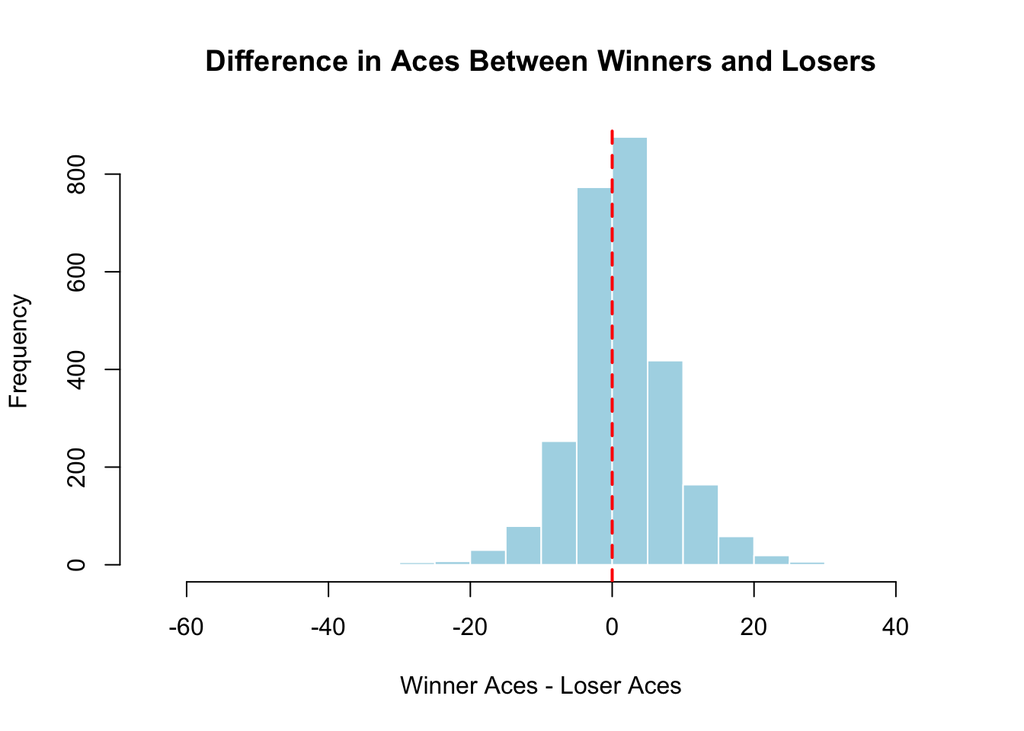

```r
hist(
  aces$ace_diff,
  breaks = 30,
  main = "Difference in Aces Between Winners and Losers",
  xlab = "Winner Aces - Loser Aces",
  col = "lightblue",
  border = "white"
)

abline(v = 0, col = "red", lwd = 2, lty = 2)
```

Among the 2,694 matches with complete ace data, winners averaged 7.50 aces, while losers averaged 5.79 aces. The average difference was approximately 1.70 aces. The histogram also shows a slight shift toward positive differences, suggesting that winners tend to serve more aces than losers. However, this is descriptive evidence rather than a formal test of statistical significance.

## Problem 2(d)

```r
wins <- tennis[, .(
  player = winner_name,
  win = 1L
)]

# Create a table of losing players
losses <- tennis[, .(
  player = loser_name,
  win = 0L
)]

all_matches <- rbindlist(list(wins, losses))
player_stats <- all_matches[, .(
  matches = .N,
  wins = sum(win),
  losses = sum(win == 0),
  win_rate = mean(win)
), by = player]

# Restrict to players with at least 5 matches
player_stats <- player_stats[
  matches >= 5
][order(-win_rate)]


head(player_stats, 10)
```

```
                player matches  wins losses  win_rate
                <char>   <int> <int>  <int>     <num>
 1:       Rafael Nadal      69    60      9 0.8695652
 2:     Novak Djokovic      69    58     11 0.8405797
 3:      Roger Federer      66    55     11 0.8333333
 4:    Daniil Medvedev      80    59     21 0.7375000
 5:     Kevin Anderson      15    11      4 0.7333333
 6:      Dominic Thiem      69    50     19 0.7246377
 7:      Attila Balazs      10     7      3 0.7000000
 8: Stefanos Tsitsipas      80    55     25 0.6875000
 9:     Alex De Minaur      62    42     20 0.6774194
10:      Kei Nishikori      43    29     14 0.6744186
```

```r
player_stats[win_rate == max(win_rate)]
```

```
         player matches  wins losses  win_rate
         <char>   <int> <int>  <int>     <num>
1: Rafael Nadal      69    60      9 0.8695652
```

Among players who played at least five matches in 2019, Rafael Nadal had the highest win rate of approximately 86.96%. He won 60 out of 69 matches and lost only 9.

## Problem 3(a)

```r
library(dplyr)
library(plotly)
covid <- read.csv(
  "https://raw.githubusercontent.com/nytimes/covid-19-data/refs/heads/master/rolling-averages/us-states.csv"
)

covid$date <- as.Date(covid$date)
```

```r
covid_us <- covid |>
  filter(state %in% state.name | state == "District of Columbia") |>
  group_by(date) |>
  summarise(
    total_cases = sum(cases_avg, na.rm = TRUE),
    .groups = "drop"
  ) |>
  arrange(date)


plot_ly(
  data = covid_us,
  x = ~date,
  y = ~total_cases,
  type = "scatter",
  mode = "lines",
  height = 450,
  line = list(color = "steelblue", width = 2),
  hovertemplate = paste0(
    "Date: %{x|%Y-%m-%d}<br>",
    "Daily cases: %{y:,.0f}",
    "<extra></extra>"
  )
) |>
  layout(
    title = list(
      text = "COVID-19 Waves in the US",
      x = 0.5,
      font = list(size = 18)
    ),
    xaxis = list(
      title = "Date",
      tickformat = "%Y",
      showgrid = FALSE
    ),
    yaxis = list(
      title = "Daily Cases (7-Day Average)",
      tickformat = ",.0f",
      rangemode = "tozero",
      gridcolor = "#E5E5E5",
      automargin = TRUE
    ),
    plot_bgcolor = "white",
    paper_bgcolor = "white",
    font = list(size = 12, color = "#333333"),
    margin = list(l = 90, r = 25, t = 60, b = 90),
    annotations = list(
      list(
        text = "Source: The New York Times",
        x = 0,
        y = -0.23,
        xref = "paper",
        yref = "paper",
        showarrow = FALSE,
        xanchor = "left",
        font = list(size = 10, color = "gray")
      )
    )
  )
```

[interactive chart not shown]

The plot shows approximately three major spikes in COVID-19 cases, occurring in early 2021, late summer 2021, and early 2022, along with four smaller spikes. The largest spike occurred in early 2022, reaching approximately 800,000 daily new cases.

## Problem 3(b)

```r
state_rates <- covid |>
  filter(state %in% state.name) |>
  group_by(state) |>
  summarise(
    total_rate = sum(cases_avg_per_100k, na.rm = TRUE),
    .groups = "drop"
  ) |>
  arrange(desc(total_rate))

highest_state <- state_rates |>
  slice_max(total_rate, n = 1)

lowest_state <- state_rates |>
  slice_min(total_rate, n = 1)

highest_state
```

```
# A tibble: 1 × 2
  state        total_rate
  <chr>             <dbl>
1 Rhode Island     43296.
```

```r
lowest_state
```

```
# A tibble: 1 × 2
  state total_rate
  <chr>      <dbl>
1 Maine     22020.
```

```r
selected_states <- c(
  highest_state$state,
  lowest_state$state
)

covid_compare <- covid |>
  filter(state %in% selected_states) |>
  arrange(state, date)

plot_ly(
  data = covid_compare,
  x = ~date,
  y = ~cases_avg_per_100k,
  color = ~state,
  colors = c("#0072B2", "#D55E00"),
  type = "scatter",
  mode = "lines",
  height = 450,
  line = list(width = 2),
  hovertemplate = paste0(
    "Date: %{x|%Y-%m-%d}<br>",
    "Cases per 100k: %{y:.2f}"
  )
) |>
  layout(
    title = list(
      text = "COVID-19 Trends: Highest vs. Lowest Rate",
      x = 0.5,
      font = list(size = 16)
    ),
    xaxis = list(
      title = "Date",
      tickformat = "%Y",
      showgrid = FALSE
    ),
    yaxis = list(
      title = "Daily Cases per 100,000",
      rangemode = "tozero",
      gridcolor = "#E5E5E5",
      automargin = TRUE
    ),
    legend = list(
      orientation = "h",
      x = 0.5,
      xanchor = "center",
      y = 1.05
    ),
    plot_bgcolor = "white",
    paper_bgcolor = "white",
    font = list(size = 12, color = "#333333"),
    margin = list(l = 80, r = 25, t = 90, b = 90),
    annotations = list(
      list(
        text = "Source: The New York Times",
        x = 0,
        y = -0.23,
        xref = "paper",
        yref = "paper",
        showarrow = FALSE,
        xanchor = "left",
        font = list(size = 10, color = "gray")
      )
    )
  )
```

[interactive chart not shown]

Rhode Island had the highest overall COVID-19 case rate, with approximately 43,296 cases per 100,000 people, while Maine had the lowest, with approximately 22,020 cases per 100,000 people. Both states experienced similar epidemic waves, but Rhode Island had substantially higher peaks, particularly in early 2022, when daily cases reached approximately 500 per 100,000 people. Maine experienced smaller and less pronounced peaks throughout the pandemic.

## Problem 3(c)

```r
threshold <- 10

first_five <- covid |>
  filter(
    state %in% state.name,
    cases_avg_per_100k >= threshold
  ) |>
  group_by(state) |>
  summarise(
    first_date = min(date),
    .groups = "drop"
  ) |>
  arrange(first_date, state) |>
  slice_head(n = 5)

first_five
```

```
# A tibble: 5 × 2
  state         first_date
  <chr>         <date>
1 New York      2020-03-22
2 New Jersey    2020-03-27
3 Massachusetts 2020-03-30
4 Connecticut   2020-03-31
5 Louisiana     2020-03-31
```

```r
start_date <- min(covid$date, na.rm = TRUE)

first_five <- first_five |>
  mutate(
    days = as.numeric(first_date - start_date),
    date_label = format(first_date, "%b %d, %Y")
  )

first_five
```

```
# A tibble: 5 × 4
  state         first_date  days date_label
  <chr>         <date>     <dbl> <chr>
1 New York      2020-03-22    61 Mar 22, 2020
2 New Jersey    2020-03-27    66 Mar 27, 2020
3 Massachusetts 2020-03-30    69 Mar 30, 2020
4 Connecticut   2020-03-31    70 Mar 31, 2020
5 Louisiana     2020-03-31    70 Mar 31, 2020
```

```r
plot_ly(
  data = first_five,
  x = ~days,
  y = ~state,
  type = "bar",
  orientation = "h",
  height = 450,
  marker = list(color = "steelblue"),
  text = ~date_label,
  textposition = "outside",
  cliponaxis = FALSE,
  hovertemplate = paste0(
    "State: %{y}<br>",
    "Date: %{text}<br>",
    "Days since start: %{x}",
    "<extra></extra>"
  )
) |>
  layout(
    title = list(
      text = "First Five States to Reach 10 Cases per 100k",
      x = 0.5,
      font = list(size = 16)
    ),
    xaxis = list(
      title = "Days Since Start of Dataset",
      range = c(0, max(first_five$days) * 1.4),
      gridcolor = "#E5E5E5"
    ),
    yaxis = list(
      title = "",
      categoryorder = "array",
      categoryarray = rev(first_five$state),
      automargin = TRUE
    ),
    plot_bgcolor = "white",
    paper_bgcolor = "white",
    font = list(size = 12, color = "#333333"),
    margin = list(l = 120, r = 40, t = 70, b = 90),
    annotations = list(
      list(
        text = "Source: The New York Times",
        x = 0,
        y = -0.23,
        xref = "paper",
        yref = "paper",
        showarrow = FALSE,
        xanchor = "left",
        font = list(size = 10, color = "gray")
      )
    )
  )
```

[interactive chart not shown]

Using a threshold of 10 daily new cases per 100,000 people based on the seven-day rolling average, New York was the first state to experience substantial COVID-19 spread on March 22, 2020, followed by New Jersey on March 27 and Massachusetts on March 30. Connecticut and Louisiana both reached the threshold on March 31. Four of these five states are located in the northeastern United States, suggesting that the Northeast was particularly affected during the early stage of the pandemic.